# IA para Científicos Sociales

Sesión 3.3: Laboratorio - Clustering y PCA

Danilo Freire

danilofreire@gmail.com

Departament of Data and Decision Sciences  
Emory University

# Laboratorio 5: Clustering y PCA

## Objetivos del laboratorio

**Lo que vamos a hacer:**

1. Explorar 8 indicadores de 18 países
2. Aplicar K-means y evaluar clusters
3. Usar el método del codo y silueta
4. Ejecutar PCA e interpretar componentes
5. Visualizar con biplot

**Lo que queremos descubrir:**

- ¿Qué países se parecen entre sí?
- ¿Cuántos grupos distintos hay?
- ¿Qué dimensiones ocultas resumen las 8 variables?
- ¿Es el desarrollo una sola cosa o varias?

Trabajen en sus computadoras. Intenten resolver los ejercicios antes de mirar la solución. Clustering jerárquico y ejercicios adicionales están en los apéndices.

# Parte 1: Exploración de datos

## Cargar paquetes

```r
R> # Instalar si es necesario
R> paquetes <- c("tidyverse", "cluster", "factoextra", "dendextend", "corrplot")
R>
R> for (pkg in paquetes) {
+   if (!require(pkg, character.only = TRUE)) {
+     install.packages(pkg, dependencies = TRUE)
+     library(pkg, character.only = TRUE)
+   }
+ }
R>
R> library(tidyverse)
R> library(cluster)      # Para silhouette()
R> library(factoextra)   # Para fviz_cluster() y fviz_pca()
R> library(dendextend)   # Para dendrogramas bonitos
R> library(corrplot)     # Para matriz de correlación
R>
R> set.seed(2026)
```

## Cargar y explorar los datos

```r
R> # Cargar indicadores por país
R> paises <- read_csv("datos/indicadores_paises.csv", show_col_types = FALSE)
R>
R> # Vista general
R> glimpse(paises)
```

```
Rows: 18
Columns: 9
$ pais              <chr> "Argentina", "Bolivia", "Brasil", "Chile", "Colombia…
$ pib_per_capita    <dbl> 10756, 3276, 8942, 15375, 5900, 11745, 5979, 4094, 5…
$ esperanza_vida    <dbl> 76.3, 71.7, 75.8, 80.2, 76.9, 80.7, 77.0, 73.7, 74.6…
$ anios_educacion   <dbl> 10.7, 8.8, 8.1, 10.1, 8.1, 8.9, 8.1, 7.1, 5.4, 6.9, …
$ acceso_internet   <dbl> 86.5, 53.2, 80.1, 87.3, 73.1, 80.2, 64.2, 50.7, 44.3…
$ gasto_salud_pib   <dbl> 10.3, 6.7, 9.7, 9.1, 8.1, 8.0, 8.2, 7.4, 5.6, 7.7, 5…
$ indice_gini       <dbl> 41.3, 44.3, 48.7, 45.4, 50.4, 48.1, 44.9, 38.6, 47.8…
$ urbanizacion      <dbl> 91.7, 69.8, 86.7, 87.3, 81.3, 81.0, 64.0, 73.3, 51.7…
$ indice_democracia <dbl> 6.7, 4.4, 7.0, 8.1, 7.0, 8.3, 5.7, 5.8, 4.9, 5.4, 5.…
```

## Variables del dataset

| Variable | Descripción |
| --- | --- |
| `pib_per_capita` | PIB per cápita en USD |
| `esperanza_vida` | Esperanza de vida al nacer (años) |
| `anios_educacion` | Años promedio de escolaridad |
| `acceso_internet` | % de población con acceso a internet |
| `gasto_salud_pib` | Gasto en salud como % del PIB |
| `indice_gini` | Índice de Gini (desigualdad, 0-100) |
| `urbanizacion` | % de población urbana |
| `indice_democracia` | Índice de democracia (0-10) |

Todas las variables son numéricas. Ideal para clustering y PCA.

## Estadísticas descriptivas

```r
R> # Resumen de cada variable
R> paises |>
+   select(-pais) |>
+   summary()
```

```
 pib_per_capita  esperanza_vida  anios_educacion  acceso_internet
 Min.   : 1881   Min.   :71.70   Min.   : 5.400   Min.   :30.30
 1st Qu.: 4329   1st Qu.:74.22   1st Qu.: 7.725   1st Qu.:55.70
 Median : 6108   Median :75.55   Median : 8.300   Median :71.00
 Mean   : 7971   Mean   :75.87   Mean   : 8.406   Mean   :66.39
 3rd Qu.:10636   3rd Qu.:76.97   3rd Qu.: 8.975   3rd Qu.:78.80
 Max.   :17185   Max.   :80.70   Max.   :10.700   Max.   :88.20
 gasto_salud_pib   indice_gini     urbanizacion   indice_democracia
 Min.   : 4.200   Min.   :38.60   Min.   :51.70   Min.   :2.100
 1st Qu.: 5.875   1st Qu.:42.58   1st Qu.:65.17   1st Qu.:5.425
 Median : 7.550   Median :45.50   Median :79.70   Median :6.350
 Mean   : 7.383   Mean   :45.29   Mean   :75.66   Mean   :6.061
 3rd Qu.: 8.275   3rd Qu.:48.02   3rd Qu.:85.72   3rd Qu.:6.925
 Max.   :10.300   Max.   :52.30   Max.   :95.00   Max.   :8.700
```

Las variables tienen escalas muy diferentes (PIB en miles vs. índices de 0-10). Es necesario escalar antes de aplicar K-means o PCA.

## Matriz de correlación

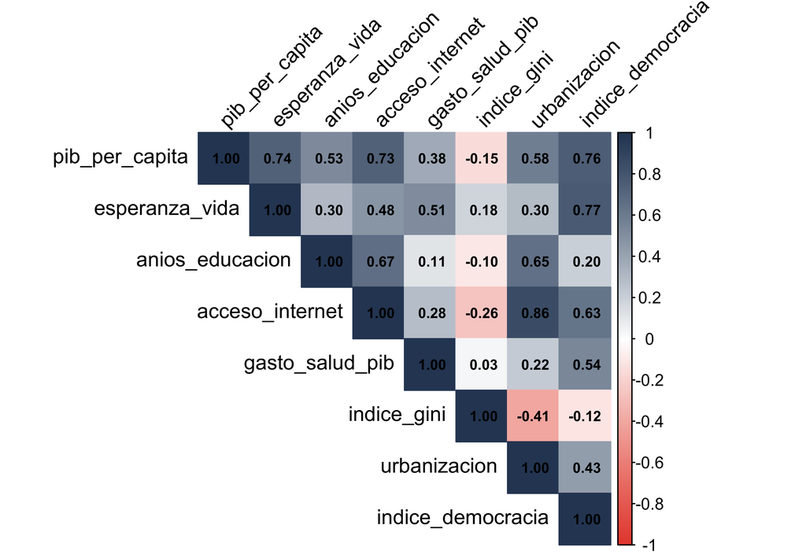

```r
R> # Calcular correlaciones
R> cor_matrix <- paises |>
+   select(-pais) |>
+   cor()
R>
R> # Visualizar
R> corrplot(cor_matrix, method = "color", type = "upper",
+          addCoef.col = "black", number.cex = 0.7,
+          tl.col = "black", tl.srt = 45,
+          col = colorRampPalette(c("#E74C3C", "white", "#2d4563"))(200))
```

## Interpretación de correlaciones

**Correlaciones positivas fuertes:**

- Internet ↔︎ urbanización: **0.86**
- Esperanza de vida ↔︎ democracia: **0.77**
- PIB ↔︎ democracia: **0.76**
- PIB ↔︎ esperanza de vida: **0.74**
- PIB ↔︎ internet: **0.73**
- Internet ↔︎ educación: **0.67**

Estas variables “van juntas”: los países con mayor PIB tienen mejor educación, salud, democracia e internet.

**Correlaciones negativas:**

- Gini ↔︎ urbanización: **-0.41**
- Gini ↔︎ internet: **-0.26**
- Gini ↔︎ PIB: **-0.15**

Los países más desiguales tienden a ser menos urbanos y con menor acceso a internet. La correlación Gini ↔︎ democracia es **-0.12**, casi nula.

Varias variables “apuntan en la misma dirección”: el PCA las resumirá en un “eje de desarrollo”.

## Ejercicio rápido: dos países

Elige dos países del dataset que te interesen (por ejemplo, Uruguay vs. Honduras, Chile vs. Bolivia, o Argentina vs. Venezuela). Compara sus valores en las 8 variables.

**Preguntas:**

- ¿Cuál parece más desarrollado?
- ¿En qué variable es mayor la diferencia?
- ¿Hay alguna variable en la que el “menos desarrollado” supere al otro?

*Pista:* usen `paises |> filter(pais %in% c("...", "..."))` y `select()` con las variables que quieran comparar.

Tómense 3 minutos para experimentar.

Apéndice: Solución

## Preparar datos para clustering

```r
R> # Guardar nombres de países
R> nombres <- paises$pais
R>
R> # Seleccionar solo variables numéricas
R> datos_num <- paises |>
+   select(-pais)
R>
R> # Escalar (media = 0, sd = 1)
R> datos_scaled <- scale(datos_num) |>
+   as.data.frame()
R>
R> # Asignar nombres de países como rownames
R> rownames(datos_scaled) <- nombres
R>
R> # Verificar
R> head(datos_scaled, 5)
```

```
          pib_per_capita esperanza_vida anios_educacion acceso_internet
Argentina      0.5937295     0.17882893       1.6006861       1.1829170
Bolivia       -1.0007920    -1.71950893       0.2751785      -0.7762995
Brasil         0.2070367    -0.02751214      -0.2131664       0.8063709
Chile          1.5783679     1.78828929       1.1821047       1.2299853
Colombia      -0.4414304     0.42643822      -0.2131664       0.3945236
          gasto_salud_pib indice_gini urbanizacion indice_democracia
Argentina       1.6825368 -1.01330353    1.2641504         0.3835748
Bolivia        -0.3941943 -0.25226889   -0.4613624        -0.9972946
Brasil          1.3364149  0.86391525    0.8701977         0.5636882
Chile           0.9902931  0.02677714    0.9174721         1.2241040
Colombia        0.4134233  1.29516821    0.4447288         0.5636882
```

# Parte 2: K-means y evaluación

## ¿Qué buscamos con el clustering?

La hipótesis: los 18 países latinoamericanos no son todos iguales en desarrollo. K-means los dividirá en grupos “parecidos entre sí”.

**Preguntas que queremos responder:**

- ¿Cuántos grupos realmente distintos hay? (¿2, 3, 4?)
- ¿Qué países entran en cada grupo?
- ¿Los grupos corresponden a niveles de desarrollo, o a otra dimensión?
- ¿El resultado es estable o sensible al número K elegido?

Métrica de éxito: que los grupos tengan sentido sustantivo (países parecidos juntos) y que lo confirmen métricas como la silueta y el método del codo.

## Ejecutar K-means con K=2

```r
R> # K-means con 2 clusters
R> km2 <- kmeans(datos_scaled, centers = 2, nstart = 25)
R>
R> # Ver resultados
R> km2$cluster
```

```
           Argentina              Bolivia               Brasil
                   1                    2                    1
               Chile             Colombia           Costa Rica
                   1                    1                    1
             Ecuador          El Salvador            Guatemala
                   2                    2                    2
            Honduras               México            Nicaragua
                   2                    2                    2
              Panamá             Paraguay                 Perú
                   1                    2                    2
República Dominicana              Uruguay            Venezuela
                   2                    1                    2
```

```r
R> # Agregar al dataframe original
R> paises$cluster_km2 <- factor(km2$cluster)
```

## Visualizar los clusters

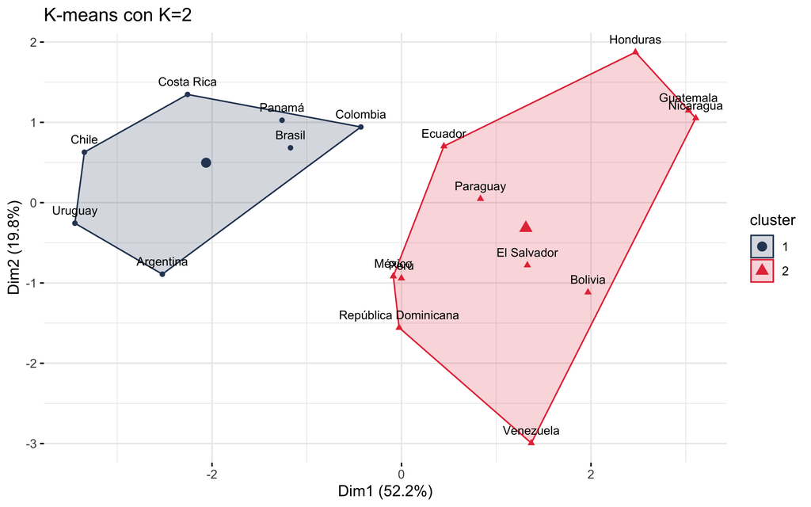

```r
R> # Visualización con factoextra (usa PCA automáticamente)
R> fviz_cluster(km2, data = datos_scaled,
+              palette = c("#2d4563", "#e63946"),
+              geom = "point",
+              ellipse.type = "convex",
+              ggtheme = theme_minimal()) +
+   geom_text(aes(label = nombres), vjust = -1, size = 3) +
+   labs(title = "K-means con K=2")
```

## ¿Qué países están en cada cluster?

```r
R> # Listar países por cluster
R> paises |>
+   select(pais, cluster_km2) |>
+   arrange(cluster_km2) |>
+   group_by(cluster_km2) |>
+   summarise(paises = paste(pais, collapse = ", "))
```

```
# A tibble: 2 × 2
  cluster_km2 paises
  <fct>       <chr>
1 1           Argentina, Brasil, Chile, Colombia, Costa Rica, Panamá, Uruguay
2 2           Bolivia, Ecuador, El Salvador, Guatemala, Honduras, México, Nicar…
```

## Perfil de cada cluster

```r
R> # Medias por cluster (datos originales, no escalados)
R> paises |>
+   group_by(cluster_km2) |>
+   summarise(
+     n = n(),
+     pib_mean = round(mean(pib_per_capita)),
+     vida_mean = round(mean(esperanza_vida), 1),
+     educ_mean = round(mean(anios_educacion), 1),
+     inet_mean = round(mean(acceso_internet), 1),
+     gini_mean = round(mean(indice_gini), 1),
+     demo_mean = round(mean(indice_democracia), 1)
+   )
```

```
# A tibble: 2 × 8
  cluster_km2     n pib_mean vida_mean educ_mean inet_mean gini_mean demo_mean
  <fct>       <int>    <dbl>     <dbl>     <dbl>     <dbl>     <dbl>     <dbl>
1 1               7    12234      78         9.2      79.8      46.1       7.5
2 2              11     5258      74.5       7.9      57.9      44.8       5.1
```

¿Los dos clusters corresponden a “más desarrollados” vs. “menos desarrollados”? ¿En qué variable se diferencian más?

## Método del codo

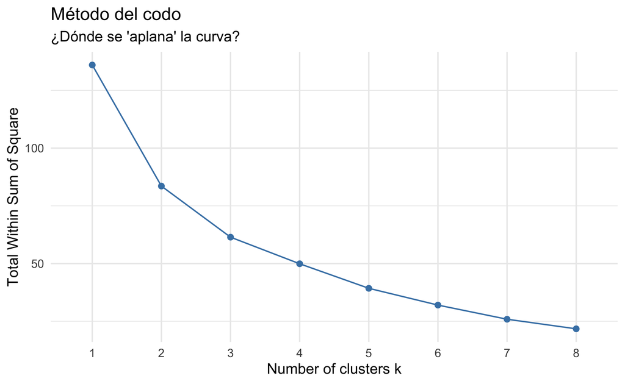

```r
R> # Calcular WSS para K=1 a K=8
R> fviz_nbclust(datos_scaled, kmeans,
+              method = "wss",
+              k.max = 8,
+              nstart = 25) +
+   labs(title = "Método del codo",
+        subtitle = "¿Dónde se 'aplana' la curva?") +
+   theme_minimal()
```

La mayor caída va de K=1 a K=2. Después la curva se aplana: K=2 es el codo.

## Método de la silueta

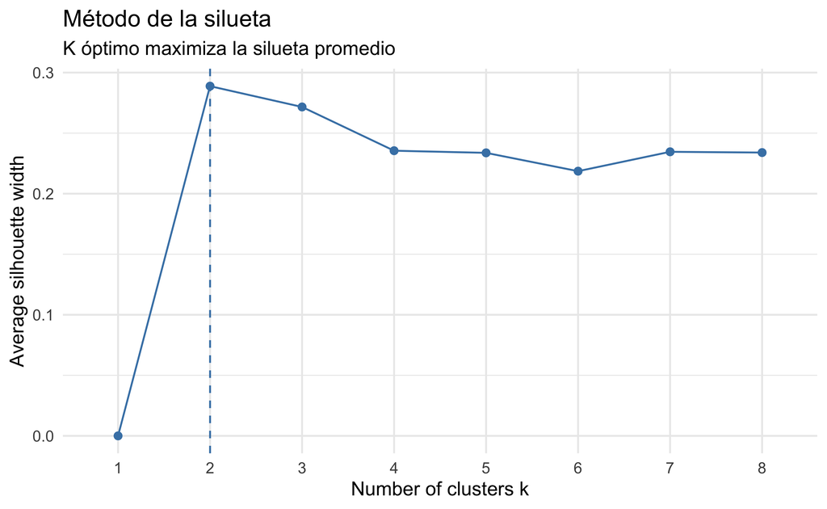

```r
R> # Calcular silueta promedio para K=2 a K=8
R> fviz_nbclust(datos_scaled, kmeans,
+              method = "silhouette",
+              k.max = 8,
+              nstart = 25) +
+   labs(title = "Método de la silueta",
+        subtitle = "K óptimo maximiza la silueta promedio") +
+   theme_minimal()
```

El pico está en K=2 (silueta ≈ 0.29). Codo y silueta coinciden: dos grupos es la solución más defendible.

## Silueta detallada para K=2

```
  cluster size ave.sil.width
1       1    7          0.32
2       2   11          0.27
```

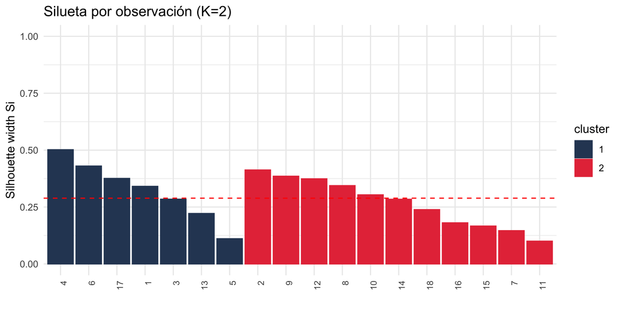

```r
R> # Calcular silueta para cada observación
R> sil <- silhouette(km2$cluster, dist(datos_scaled))
R>
R> # Visualizar
R> fviz_silhouette(sil, palette = c("#2d4563", "#e63946")) +
+   labs(title = "Silueta por observación (K=2)") +
+   theme_minimal() +
+   theme(axis.text.x = element_text(angle = 90, hjust = 1, size = 8))
```

## Interpretación de la silueta

**Silueta promedio:**

```r
R> mean(sil[, 3])
```

```
[1] 0.2888078
```

Un valor de ~0.29 indica estructura débil pero visible.

**Observaciones con silueta negativa:**

Están mal clasificadas (más cerca del otro cluster).

**Regla de interpretación:**

| Valor | Significado |
| --- | --- |
| > 0.7 | Fuerte |
| 0.5 - 0.7 | Razonable |
| 0.25 - 0.5 | Débil |
| < 0.25 | Sin estructura |

Con solo 18 países, es difícil obtener siluetas muy altas.

## Ejercicio rápido: ¿y si probamos K=3?

Codo y silueta apuntan a K=2, pero K=3 está muy cerca. Prueba a dividir los países en 3 grupos y compara.

**Instrucciones:**

1. Ejecuta `kmeans(datos_scaled, centers = 3, nstart = 25)` y guárdalo en `km3`
2. Calcula la silueta promedio con `silhouette(km3$cluster, dist(datos_scaled))`
3. Compara con la silueta de K=2 (≈ 0.29)

**Preguntas:**

- ¿La silueta sube o baja al pasar de K=2 a K=3?
- ¿Qué países quedan en el cluster “intermedio”?
- ¿Tiene sentido ese cluster como “desarrollo medio”?

Tómense 3 minutos para experimentar.

Apéndice: Solución

# Parte 3: PCA e interpretación

## ¿Qué buscamos con el PCA?

Tenemos 8 variables. PCA las comprime en pocas dimensiones sin perder mucha información.

**Preguntas que queremos responder:**

- ¿Cuántas dimensiones bastan para resumir las 8 variables?
- ¿Qué significa cada dimensión? (¿“desarrollo”? ¿“desigualdad”? ¿otra cosa?)
- ¿Qué países están en los extremos de cada eje?
- ¿Los clusters de K-means se separan cuando los vemos en PC1 y PC2?

Métrica de éxito: que con 2 o 3 componentes expliquemos >70% de la varianza, y que los ejes tengan una interpretación sustantiva clara.

## Ejecutar PCA

```r
R> # PCA sobre datos escalados
R> pca <- prcomp(datos_scaled)
R>
R> # Resumen de varianza explicada
R> summary(pca)
```

```
Importance of components:
                          PC1    PC2    PC3     PC4     PC5    PC6     PC7
Standard deviation     2.0441 1.2575 0.9618 0.76749 0.57816 0.4060 0.38499
Proportion of Variance 0.5223 0.1977 0.1156 0.07363 0.04178 0.0206 0.01853
Cumulative Proportion  0.5223 0.7200 0.8356 0.90926 0.95104 0.9716 0.99017
                           PC8
Standard deviation     0.28043
Proportion of Variance 0.00983
Cumulative Proportion  1.00000
```

PC1 explica el 52% de la varianza y PC2 el 20%. Entre los dos resumimos el 72% de la información de las 8 variables originales.

## Scree plot

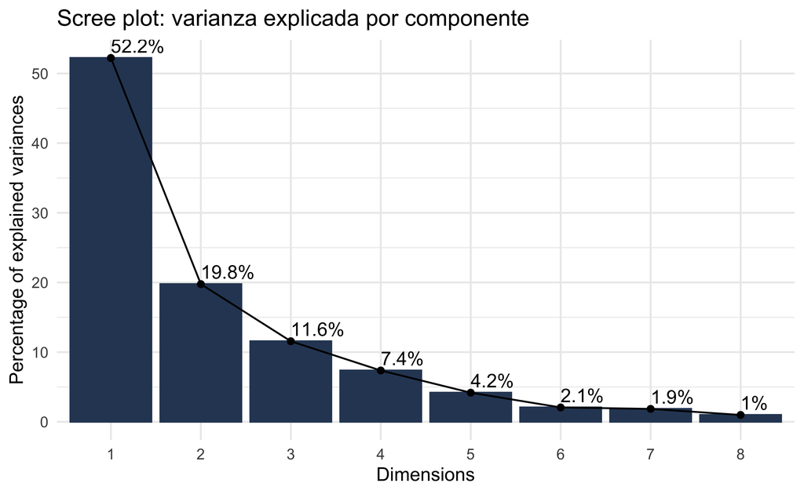

```r
R> # Varianza explicada por componente
R> fviz_eig(pca, addlabels = TRUE,
+          barfill = "#2d4563", barcolor = "#2d4563") +
+   labs(title = "Scree plot: varianza explicada por componente") +
+   theme_minimal()
```

## Loadings: ¿qué mide cada componente?

```r
R> # Loadings de los primeros 3 componentes
R> loadings <- pca$rotation[, 1:3] |>
+   as.data.frame() |>
+   rownames_to_column("variable") |>
+   arrange(desc(abs(PC1)))
R>
R> loadings
```

```
           variable        PC1         PC2         PC3
1    pib_per_capita -0.4387072  0.07337917 -0.03316035
2   acceso_internet -0.4367711 -0.22750314 -0.09784433
3 indice_democracia -0.4003006  0.28504978  0.27826091
4      urbanizacion -0.3831576 -0.39134175 -0.02000521
5    esperanza_vida -0.3651244  0.43128497 -0.09126237
6   anios_educacion -0.3159903 -0.32026263 -0.53929448
7   gasto_salud_pib -0.2547500  0.39962818  0.31365683
8       indice_gini  0.1079509  0.51007697 -0.71690276
```

## Interpretación de PC1 y PC2

**PC1 (52% varianza):**

Cargas altas (en valor absoluto) en:

- PIB (0.44), internet (0.44)
- Democracia (0.40), urbanización (0.38)
- Esperanza de vida (0.37), educación (0.32)

→ Eje de desarrollo general

**PC2 (20% varianza):**

Cargas altas en:

- Índice de Gini (0.51)
- Esperanza de vida (0.43)
- Gasto en salud (0.40)

Cargas negativas en:

- Urbanización (-0.39), educación (-0.32)

→ Contraste desigualdad / urbanización

Separa países desiguales pero con buena salud de países más urbanos y educados.

## Ejercicio rápido: ¿qué país está en los extremos?

Ordena los países por su valor en PC1 para identificar los más “desarrollados” y los menos, según esta medida resumen.

**Instrucciones:**

1. Extrae las coordenadas PC1 y PC2 desde `pca$x[, 1:2]`
2. Convierte a `data.frame` y agrega los nombres de países con `rownames_to_column("pais")`
3. Ordena por PC1 con `arrange(PC1)`

**Preguntas:**

- ¿Coincide el ranking con tu intuición sobre el desarrollo latinoamericano?
- ¿Qué país te sorprende más (arriba o abajo)?
- ¿Qué países están cerca de PC1 = 0, en el “medio”?

Tómense 3 minutos para experimentar.

Apéndice: Solución

## Biplot

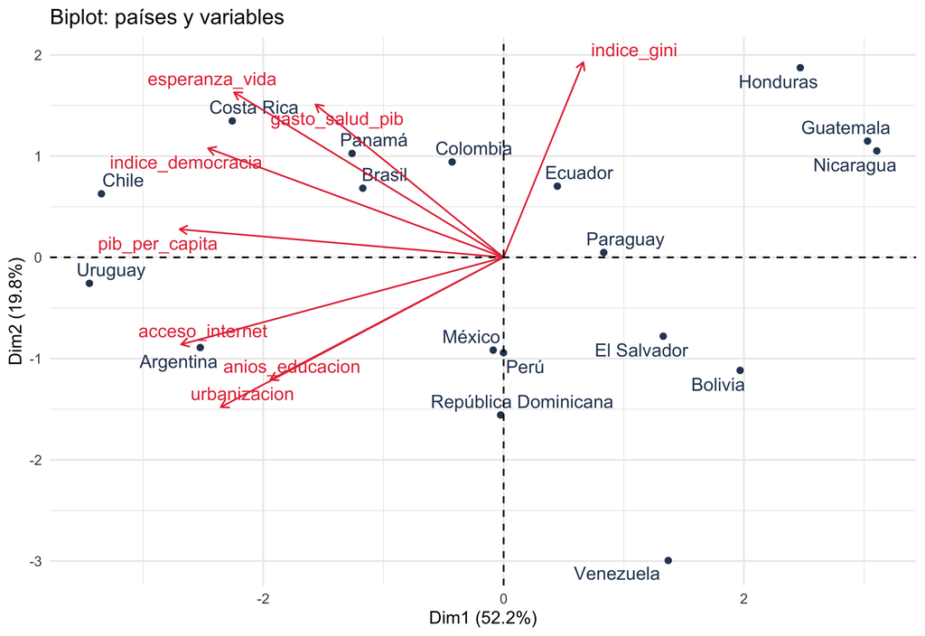

```r
R> # Biplot con factoextra
R> fviz_pca_biplot(pca,
+                 repel = TRUE,
+                 col.var = "#e63946",
+                 col.ind = "#2d4563",
+                 label = "all") +
+   labs(title = "Biplot: países y variables") +
+   theme_minimal()
```

# Ejercicios adicionales

## Ejercicio 1: Probar K=4

**Instrucciones:**

1. Ejecutar K-means con K=4
2. Visualizar los clusters
3. Calcular la silueta
4. ¿Mejora respecto a K=2?

```r
R> km4 <- kmeans(datos_scaled, centers = 4, nstart = 25)
R>
R> # Silueta promedio
R> sil4 <- silhouette(km4$cluster, dist(datos_scaled))
R> mean(sil4[, 3])
```

```
[1] 0.2354994
```

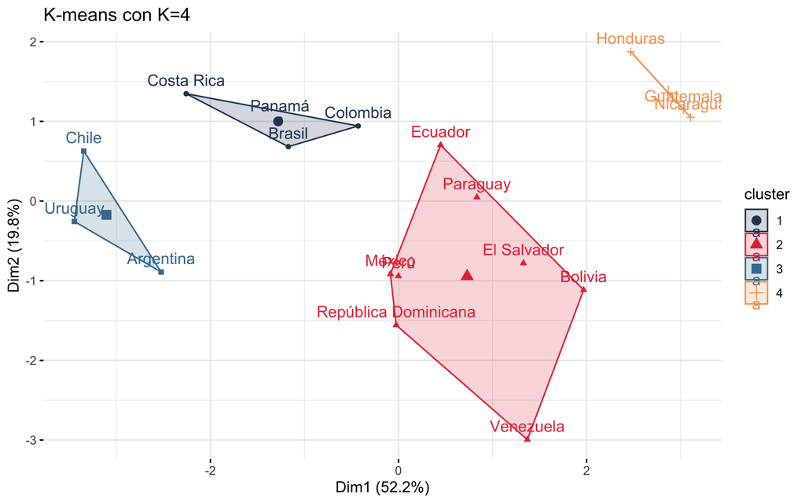

```r
R> # Visualizar
R> fviz_cluster(km4, data = datos_scaled,
+              palette = c("#2d4563", "#e63946", "#457b9d", "#f4a261"),
+              ggtheme = theme_minimal()) +
+   labs(title = "K-means con K=4")
```

## Resumen del laboratorio

**Lo que practicamos:**

- Exploración y escalado de datos
- K-means con evaluación (codo, silueta)
- PCA con interpretación de loadings
- Biplot para visualizar países y variables

**Funciones clave:**

- `scale()`: normalizar datos
- `kmeans()`: clustering
- `silhouette()`: evaluar clusters
- `prcomp()`: PCA
- `fviz_*()`: visualizaciones

En el próximo laboratorio aplicaremos análisis de texto. En los apéndices: clustering jerárquico y ejercicios adicionales.

# Apéndice: Soluciones de ejercicios rápidos

## Solución: dos países

```r
R> paises |>
+   filter(pais %in% c("Uruguay", "Honduras")) |>
+   select(pais, pib_per_capita, esperanza_vida, anios_educacion,
+          acceso_internet, indice_gini, indice_democracia)
```

```
# A tibble: 2 × 7
  pais     pib_per_capita esperanza_vida anios_educacion acceso_internet
  <chr>             <dbl>          <dbl>           <dbl>           <dbl>
1 Honduras           2658           75.1             6.9            38.7
2 Uruguay           17185           78.1             8.4            88.2
# ℹ 2 more variables: indice_gini <dbl>, indice_democracia <dbl>
```

- Uruguay tiene PIB per cápita más de seis veces mayor que Honduras (17 185 vs. 2 658)
- Uruguay supera a Honduras en internet (88% vs. 39%), democracia (8.7 vs. 5.4) y urbanización (95% vs. 59%)
- Pero Honduras tiene Gini más alto (52.3 vs. 38.9): es más desigual
- El “desarrollo” no es una sola cosa: hay variables que van en distintas direcciones

Volver al ejercicio

## Solución: ¿y si probamos K=3?

```r
R> km3 <- kmeans(datos_scaled, centers = 3, nstart = 25)
R> sil3 <- silhouette(km3$cluster, dist(datos_scaled))
R> mean(sil3[, 3])
```

```
[1] 0.2716258
```

```r
R> # ¿Qué países quedan en cada cluster?
R> data.frame(pais = rownames(datos_scaled), cluster = km3$cluster) |>
+   arrange(cluster)
```

```
                                     pais cluster
Bolivia                           Bolivia       1
Ecuador                           Ecuador       1
El Salvador                   El Salvador       1
México                             México       1
Paraguay                         Paraguay       1
Perú                                 Perú       1
República Dominicana República Dominicana       1
Venezuela                       Venezuela       1
Guatemala                       Guatemala       2
Honduras                         Honduras       2
Nicaragua                       Nicaragua       2
Argentina                       Argentina       3
Brasil                             Brasil       3
Chile                               Chile       3
Colombia                         Colombia       3
Costa Rica                     Costa Rica       3
Panamá                             Panamá       3
Uruguay                           Uruguay       3
```

- Silueta con K=3: ≈ 0.27 (con K=2 era ≈ 0.29, así que baja un poco)
- El cluster “intermedio” suele contener países como Bolivia, Ecuador, México, Perú, Paraguay y República Dominicana: desarrollo medio
- El cluster “bajo” queda como Guatemala, Honduras y Nicaragua: los más pobres
- Lección: K=3 tiene sentido sustantivo aunque la silueta sea levemente peor

Volver al ejercicio

## Solución: ¿qué país está en los extremos?

```r
R> pca$x[, 1:2] |>
+   as.data.frame() |>
+   rownames_to_column("pais") |>
+   arrange(PC1) |>
+   mutate(PC1 = round(PC1, 2), PC2 = round(PC2, 2))
```

```
                   pais   PC1   PC2
1               Uruguay -3.45 -0.26
2                 Chile -3.35  0.63
3             Argentina -2.52 -0.89
4            Costa Rica -2.26  1.35
5                Panamá -1.26  1.03
6                Brasil -1.17  0.68
7              Colombia -0.43  0.94
8                México -0.09 -0.92
9  República Dominicana -0.02 -1.56
10                 Perú  0.00 -0.94
11              Ecuador  0.45  0.70
12             Paraguay  0.83  0.05
13          El Salvador  1.33 -0.78
14            Venezuela  1.37 -2.99
15              Bolivia  1.97 -1.12
16             Honduras  2.47  1.87
17            Guatemala  3.03  1.15
18            Nicaragua  3.11  1.05
```

Volver al ejercicio

# Apéndice 1: Clustering jerárquico

## Calcular distancias y dendrograma

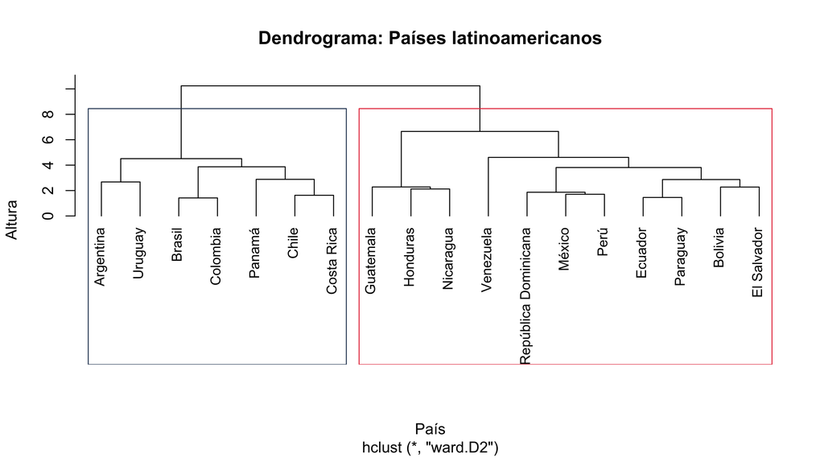

```r
R> # Matriz de distancias euclidianas
R> d <- dist(datos_scaled, method = "euclidean")
R>
R> # Clustering jerárquico con método Ward
R> hc <- hclust(d, method = "ward.D2")
R>
R> # Dendrograma con rectángulos para K=2
R> plot(hc, hang = -1, cex = 0.9,
+      main = "Dendrograma: Países latinoamericanos",
+      xlab = "País", ylab = "Altura")
R> rect.hclust(hc, k = 2, border = c("#2d4563", "#e63946"))
```

## Cortar y comparar con K-means

```r
R> # Cortar para obtener K=2 clusters
R> grupos_hc <- cutree(hc, k = 2)
R>
R> # Comparar con K-means
R> table(K_means = km2$cluster, Jerarquico = grupos_hc)
```

```
       Jerarquico
K_means  1  2
      1  7  0
      2  0 11
```

Los números de cluster son arbitrarios (cluster 1 en K-means puede ser cluster 2 en jerárquico). Lo importante es si los grupos de países coinciden.

# Apéndice 2: PCA avanzado

## PCA coloreado por cluster K-means

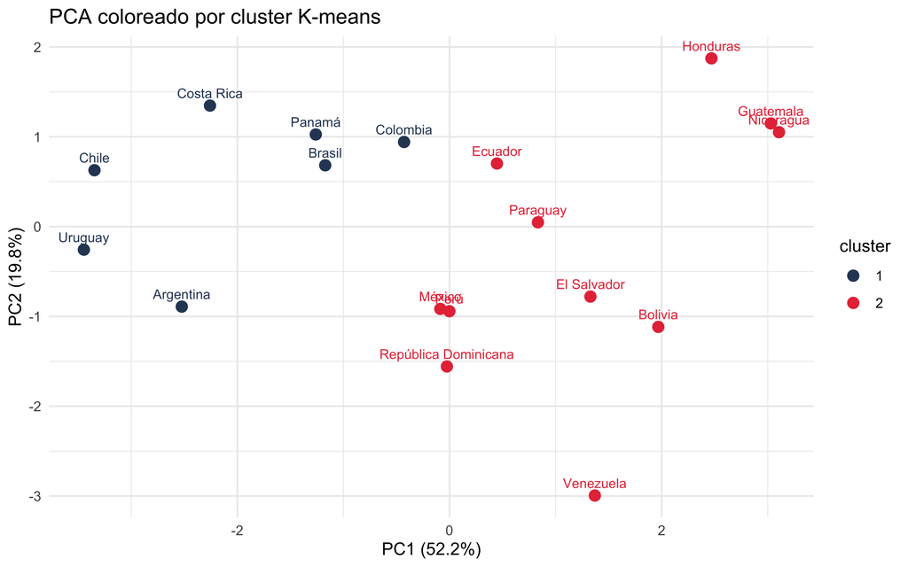

```r
R> pca_coords <- pca$x[, 1:2] |>
+   as.data.frame() |>
+   mutate(pais = nombres, cluster = paises$cluster_km2)
R>
R> ggplot(pca_coords, aes(x = PC1, y = PC2, color = cluster, label = pais)) +
+   geom_point(size = 3) +
+   geom_text(vjust = -0.8, size = 3, show.legend = FALSE) +
+   scale_color_manual(values = c("#2d4563", "#e63946")) +
+   labs(title = "PCA coloreado por cluster K-means",
+        x = paste0("PC1 (", round(summary(pca)$importance[2,1]*100, 1), "%)"),
+        y = paste0("PC2 (", round(summary(pca)$importance[2,2]*100, 1), "%)")) +
+   theme_minimal()
```

## Contribución de variables a cada componente

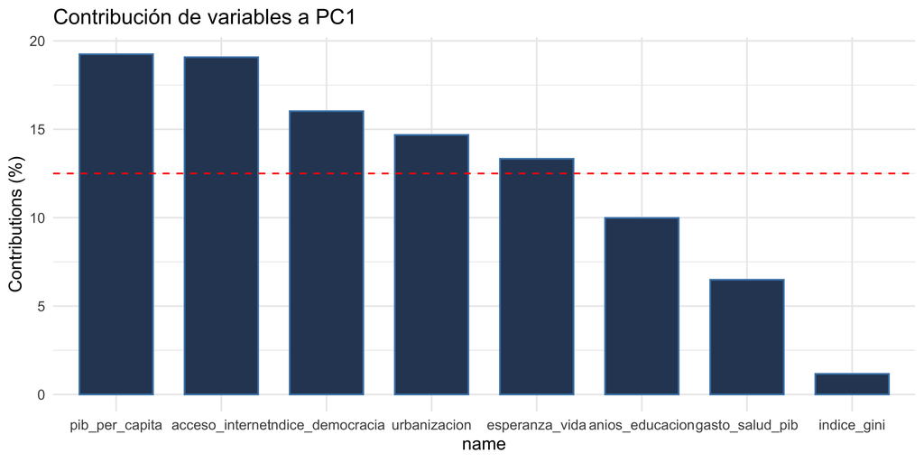

```r
R> fviz_contrib(pca, choice = "var", axes = 1, fill = "#2d4563") +
+   labs(title = "Contribución de variables a PC1") +
+   theme_minimal()
```

# Apéndice 3: Ejercicio adicional

## Ejercicio: PCA con 3 componentes

**Instrucciones:**

1. Extraer los primeros 3 componentes
2. Comparar PC1-PC2 vs. PC1-PC3
3. ¿El tercer componente agrega información útil?

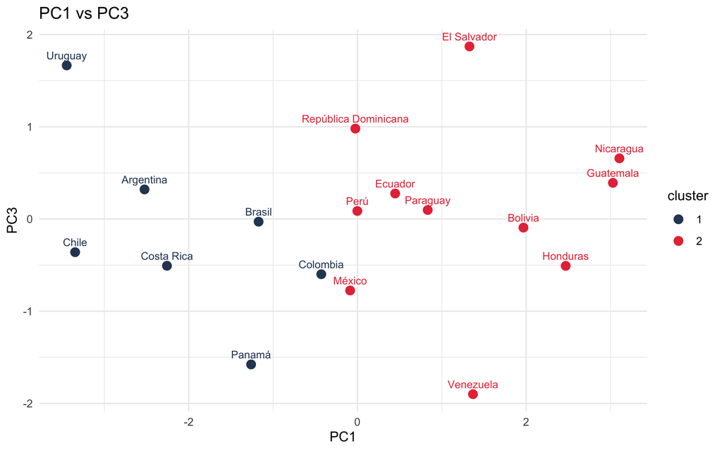

```r
R> pca_3d <- pca$x[, 1:3] |>
+   as.data.frame() |>
+   mutate(pais = nombres, cluster = paises$cluster_km2)
R>
R> ggplot(pca_3d, aes(x = PC1, y = PC3, color = cluster, label = pais)) +
+   geom_point(size = 3) +
+   geom_text(vjust = -0.8, size = 3, show.legend = FALSE) +
+   scale_color_manual(values = c("#2d4563", "#e63946")) +
+   labs(title = "PC1 vs PC3") +
+   theme_minimal()
```

# Continuar con el laboratorio de texto